# Coursework Report

*N* removed NAs: 5

*N* removed <18: 19

**Correct typo age:** 22

*N* total clean: 144

| Group | *N* | *M*<sub>age</sub> | % green |
| --- | --- | --- | --- |
| Control | 71 | 20.46 | 38.50 |
| Experim | 73 | 20.81 | 45.66 |

| Gender | *N* | *M*<sub>age</sub> | % green |
| --- | --- | --- | --- |
| Female | 70 | 20.60 | 40.00 |
| Male | 45 | 20.49 | 40.74 |
| Other | 29 | 20.97 | 49.43 |

**Main analysis results**

**car:**  
χ<sup>2</sup>(1) = 0.02, *p* = .883

**cleaner:**  
χ<sup>2</sup>(1) = 5.74, *p* = .017

**dishwasher:**  
χ<sup>2</sup>(1) = 0.04, *p* = .841

[interactive chart not shown]

[figure not shown]

[interactive chart not shown]

# Coursework Report

Analysing Data, Spring 2020

# Methods

## Participants

Table 1 *Descriptive statistics by Gender*

| Gender | *N* | *%* | *M<sub>age</sub>* | *SD<sub>age</sub>* |
| --- | --- | --- | --- | --- |
| female | 210 | 48.95 | 20.60 | 1.72 |
| male | 135 | 31.47 | 20.49 | 1.83 |
| other | 84 | 19.58 | 20.93 | 2.05 |

Table 2 *Descriptive statistics by Category*

| Category | *N* | *%* | *M<sub>age</sub>* | *SD<sub>age</sub>* |
| --- | --- | --- | --- | --- |
| luxury | 247 | 57.58 | 20.58 | 1.72 |
| green | 182 | 42.42 | 20.70 | 1.96 |

Table 3 *Descriptive statistics by Gender and Category*

| Gender | Category | *N* | *%* | *M<sub>age</sub>* | *SD<sub>age</sub>* |
| --- | --- | --- | --- | --- | --- |
| female | luxury | 126 | 29.37 | 20.74 | 1.65 |
| female | green | 84 | 19.58 | 20.39 | 1.82 |
| male | luxury | 80 | 18.65 | 20.43 | 1.85 |
| male | green | 55 | 12.82 | 20.58 | 1.81 |
| other | luxury | 41 | 9.56 | 20.39 | 1.67 |
| other | green | 43 | 10.02 | 21.44 | 2.25 |

## Design

A between-subjects design was used to measure the difference between two motives (status and a control). Participants read short stories designed to elicit either a sense of status (experimental condition) or have no effect on sense of status (control condition). Afterwards, participants chose between luxurious non-green items or less-luxurious green items. Participants believed they were taking part in a memory test and would need to recall aspects of the stories after choosing between various products.

It is predicted that participants primed with a story to elicit feelings of status will be more likely to choose luxurious non-green products over less-luxurious green products, when compared to the control group.

The choice made by participants will be operationalised by recording which of two levels within the factor, luxury or green, is chosen for each product (made of three levels: dishwasher, cleaner and car). In the experimental condition, a higher amount of choices for luxury than green items, compared to the control, will suggest the story has had the predicted effect on feelings of status. If the selection of luxury items is lower than or the same as the green items, and the control condition, then any effect predicted will not be present.

Therefore, it is predicted that the experimental condition will have a higher amount of luxurious non-green items chosen compared to the less-luxurious green items, and this effect will not be seen in the control condition. A chi-squared (*X<sup>2</sup>*) statistical test will be carried out to analyse the results.

# Results

From these results, it is clear that there is no significant difference between the choices made by the experimental and control condition when choosing between luxury or green cars and dishwashers. However there is a significant difference between the choices made in the cleaner category.

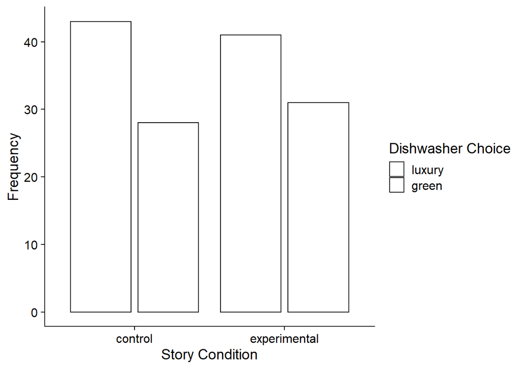

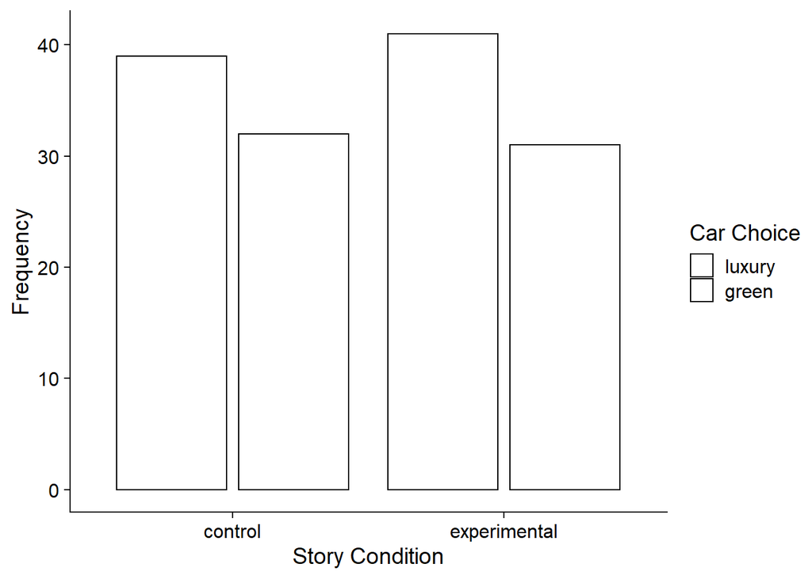

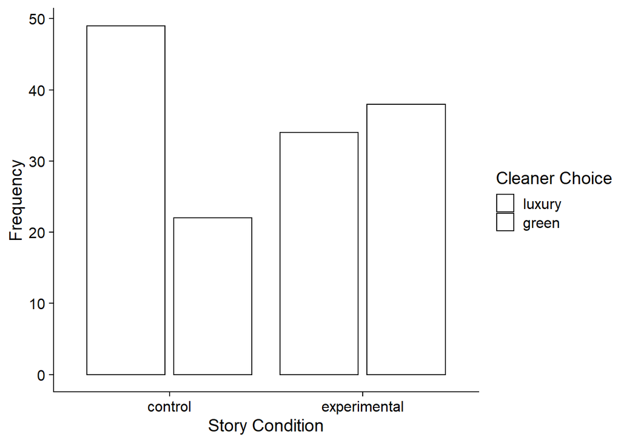

# Discussion

The results show that, contrary to what was expected, the motive of status did not have a very strong effect on whether luxurious non-green or less-luxurious green products were chosen, except for with cleaning products.

The findings of this research show that eliciting feelings of status may not be the most effective way to encourage people to buy more eco-friendly products. When compared to the original study by Griskevicius, Tybur and Van der Bergh (2010), our findings differ greatly. The original study found a significant difference between the choice options of the experimental and control conditions across all the products measured, which suggests the effect may be inconsistent throughout the general population. Perhaps there was a confounding variable common among one of the participant groups that was uncontrolled, but more studies will have to be replicated to discover what that was.

A field study replication by Van der Wal, Horen and Grinstein (2016) showed that, while eliciting feelings of higher status did provide the same results as the original study this intervention also made people with higher feelings of status want to show off their status level (Van der Wal et al., 2016). This finding suggests that the results of the current research may be influenced by a desire to be seen. That is, the cleaning products selected were less-luxurious because they would be kept in a cupboard unseen by guests, whereas the dishwasher and car could be used as signals of wealth and status to people who see them, therefore people who have higher feelings of status would want a product that displays this feeling, disregarding how green the product is. This suggestion is backed up by research that has found a link between sexual signalling (displaying worth and desirability to potential mates) and conspicuous consumption of luxurious products (Sundie, Kenrick, Griskevicius, Tybur, Vohs, & Beal, 2011). The findings of this study suggest that there was an additional uncontrolled confounding variable that influenced the results of the current study, the effect of sexual signalling. Although the present study ensured the stories provided to each participant did not include interactions with opposite-sex peers (a strength designed to limit the effect of sexual signalling), it did not take into account the attraction of people that are not heterosexual.

In addition to this replication and subsequent findings, Berger (2017) found no evidence for a ‘green-signalling’ effect (the desire to own a green product because it implies the owner is cooperative, trustworthy and able to ‘waste’ money), which corresponds with the findings of the current study. Additionally, a trend was found that corresponded with the socioeconomic status of the participant of Berger’s study. In poorer areas, luxury items were viewed with more distain (Berger, 2017), this suggests a person’s background and socioeconomic status prior to taking part in the current study may have an effect on the results of their choices after reading the story they were presented with. The current study had no way of knowing the effect a participant’s socioeconomic status may have had on the results, this may have been a variable that ended up impacting them.

From the results collected, it is clear that there is an effect present that is worth investigating. The present study was carried out on a relatively large group of participants and analysed with statistical tests that displayed whether a significant effect had occurred, and yet different results were collected from the original study. Therefore, it would be interesting to replicate this study further in order to find out which characteristics may affect the outcome of the studies. Future studies should better control for the effect of sexual signalling by taking into account the experiences of people who are attracted to the same sex, this would go some way to avoid sexual signalling impacting on the outcome of the study. Additionally, participants backgrounds, such as family wealth and upbringing, may have a significant impact on their attitudes to status and buying green. This phenomenon would produce some interesting results when studied. It would be important to investigate this further as the findings may provide information that would help advertisers of green products to appeal to a wider range of people, therefore increasing the purchase of green products by a larger population.

Overall, although the findings of the current study did not mirror those in the original (Griskevicius et al., 2010) they still provided an interesting perspective on the purchasing habits of a sample of the population when their feelings of status were experimentally influence and how these preferences could possibly be altered. The findings point towards further research that could return interesting findings that would impact the ability for green-product advertising companies to appeal to a wider audience.

# References

Berger, J. (2017). Are luxury brand labels and “green” labels costly signals of social status? An extended replication. PloS one, 12(2).

Griskevicius, V., Tybur, J. M., & Van den Bergh, B. (2010). Going green to be seen: status, reputation, and conspicuous conservation. Journal of personality and social psychology, 98(3), 392.

Sundie, J. M., Kenrick, D. T., Griskevicius, V., Tybur, J. M., Vohs, K. D., & Beal, D. J. (2011). Peacocks, Porsches, and Thorstein Veblen: Conspicuous consumption as a sexual signaling system. Journal of personality and social psychology, 100(4), 664.

van der Wal, A. J., van Horen, F., & Grinstein, A. (2016). The paradox of ‘green to be seen’: Green high-status shoppers excessively use (branded) shopping bags. International Journal of Research in Marketing, 33(1), 216-219.